# biota adjustments

**OSPAR 2022 Assessment: changes to biota data**

### France: species

Some French data are submitted with species “Mytilus”, which is ambiguous. Here is a summary of the number of measurements in species beginning with Mytilus by year

```r
biota_data$data %>%
  filter(
    country == "France",
    grepl("Mytilus", species)
  ) %>%
  with(table(species, year)) %>%
  print(zero.print = ".")
```

```
                           year
species                     1979 1980 1981 1982 1983 1984 1985 1986 1987 1988 1989 1990 1991 1992 1993
  Mytilus                      .    .    .    .    .    .    .    .    .    .    .    .    .    .    .
  Mytilus edulis              44   89  115   38   35   75  177   84  147  130   86  347   81   21   48
  Mytilus galloprovincialis    .    .    .    .    .    .    .    .    .    .    .   24    .    .    .
                           year
species                     1994 1995 1996 1997 1998 1999 2000 2001 2002 2003 2004 2005 2006 2007 2008
  Mytilus                      .    .    .    .    .    .    .    .    .    .    .    .    .    .    .
  Mytilus edulis             116  111  114   77   84   81   84   76   87   84   81   83   84   87   21
  Mytilus galloprovincialis    6    6    6    3    6    6    6    4    6    6    6    6    6    6    .
                           year
species                     2009 2010 2011 2012 2013 2014 2015 2016 2017 2018 2019 2020
  Mytilus                      .    .    .    .    .    .    .    .    .    .    3    .
  Mytilus edulis              36   36   51   99  111  108  133  219  110  152  186  172
  Mytilus galloprovincialis    .    .    .    .    .    .    .    6    9   12  101  101
```

The three Mytilus records in 2019 are from Aulne Rive droite, where a genetics project identified the sample to be M. edulis and M. galloprovincialis hybrids (Aourell 23/11/2021). The records are consequently deleted. Note that this station has only ever been sampled for mussels in 2019 and both edulis and galloprovincialis samples (presumably non-hybids) were identified there (see table below).

```r
biota_data$data <- mutate(
  biota_data$data,
  .drop = country == "France" & species == "Mytilus"
)

wk <- filter(biota_data$data, .drop)

if (!all(wk$station_name %in% "Aulne Rive droite" & wk$year == 2019))
  stop("something has changed - need to investigate")

biota_data$data %>%
  filter(
    station_name %in% "Aulne Rive droite",
    grepl("^Mytilus", species)
  ) %>%
  with(table(species, year))
```

```
                           year
species                     2019
  Mytilus                      3
  Mytilus edulis               3
  Mytilus galloprovincialis    3
```

```r
biota_data$data <- biota_data$data %>%
  filter(!.drop) %>%
  mutate(.drop = NULL)
```

### Iceland: species

Some Icelandic data are submitted with species “Mytilus”, which is ambiguous. Here is a summary of the number of measurements in species beginning with Mytilus by year

```r
biota_data$data %>%
  filter(
    country == "Iceland",
    grepl("Mytilus", species)
  ) %>%
  with(table(species, year)) %>%
  print(zero.print = ".")
```

```
                year
species          1992 1993 1994 1995 1996 1997 1998 1999 2000 2001 2002 2003 2004 2005 2006 2007 2008
  Mytilus           .    .    .    .    .    .    .    .    .    .    .    .    .    .    .    .    .
  Mytilus edulis   36   28   58   77   44   44   40   36   44   44   32   28   44   44   44   44   44
                year
species          2009 2011 2012 2013 2016 2017 2018 2019 2020
  Mytilus           .    .   44   44   28   32   32   32   28
  Mytilus edulis   40   44    .    .    .    .    .    .    .
```

Have assumed these to be Mytilus edulis.

```r
biota_data$data <- mutate(
  biota_data$data,
  .change = country == "Iceland" & species == "Mytilus"
)

if (sum(biota_data$data$.change) == 0)
  message("good news: appears to have been sorted")

biota_data$data <- mutate(
  biota_data$data,
  species = if_else(.change, "Mytilus edulis", species),
  .change = NULL
)
```

### Ireland: station issues

Some Irish stations have not been correctly matched to the station dictionary. Here is a summary of the number of measurements from these stations by year (in the last six monitoring years).

```r
wk_data <- biota_data$data %>%
  filter(
    country == "Ireland",
    is.na(station_name),
    year %in% biota_data$info$recentYears
  )

wk_data %>%
  with(table(submitted.station, year)) %>%
  print(zero.print = ".")
```

```
                 year
submitted.station 2015 2017 2018 2019 2020
       Inch Lough    4    4    3    4    3
```

- Inch Lough needs to be marked as for temporal monitoring

```r
wk_stations <- wk_data$submitted.station %>%  unique()

if (!identical(wk_stations, "Inch Lough"))
  warning("situation has changed - investigate")

biota_data$stations %>%
  filter(
    country == "Ireland",
    station %in% wk_stations
  ) %>%
  select(station, dataType, startYear, endYear, PURPM)
```

```
     station dataType startYear endYear PURPM
1 Inch Lough    CF~CW      2001      NA     S
```

This is all resolved in the code below.

```r
# sort out data

wk_data <- wk_data %>%
  select(country, submitted.station, station_name, station_code) %>%
  distinct() %>%
  mutate(
    station_name = submitted.station,
  station_code = get_station_code(station_name, "Ireland", biota_data$stations)
)

biota_data$data <- left_join(
  biota_data$data,
  wk_data,
  by = c("country", "submitted.station"),
  suffix = c("", ".new")
)

# need sd_name and sd_code as well so one of the checking routines works ok

biota_data$data <- biota_data$data %>%
  mutate(
    station_name = if_else(!is.na(station_name.new), station_name.new, station_name),
    station_code = if_else(!is.na(station_code.new), station_code.new, station_code),
    sd_name = if_else(!is.na(station_name.new), station_name.new, sd_name),
    sd_code = if_else(!is.na(station_code.new), station_code.new, sd_code)
  ) %>%
  select(-station_name.new, - station_code.new)

# update station dictionary

biota_data$stations <- biota_data$stations %>%
  mutate(
    .id = code %in% wk_data$station_code,
    .T = str_split(PURPM, "~") %>% sapply(function(x) "T" %in% x),
    .EF = str_split(dataType, "~") %>% sapply(function(x) "EF" %in% x),
    PURPM = if_else(.id & !.T, paste0(PURPM, "~T"), PURPM),
    dataType = if_else(.id & !.EF, paste0(dataType, "~EF"), dataType),
  ) %>%
  select(-.id, -.T, -.EF)

rm(wk_data, wk_stations)
```

### Ireland: HG uncertainty

Mercury data in 2016 have been reported with an implausibly tight uncertainty, which causes problems with the assessment later on. Here is a plot of the relative uncertainties by year (from 2015.

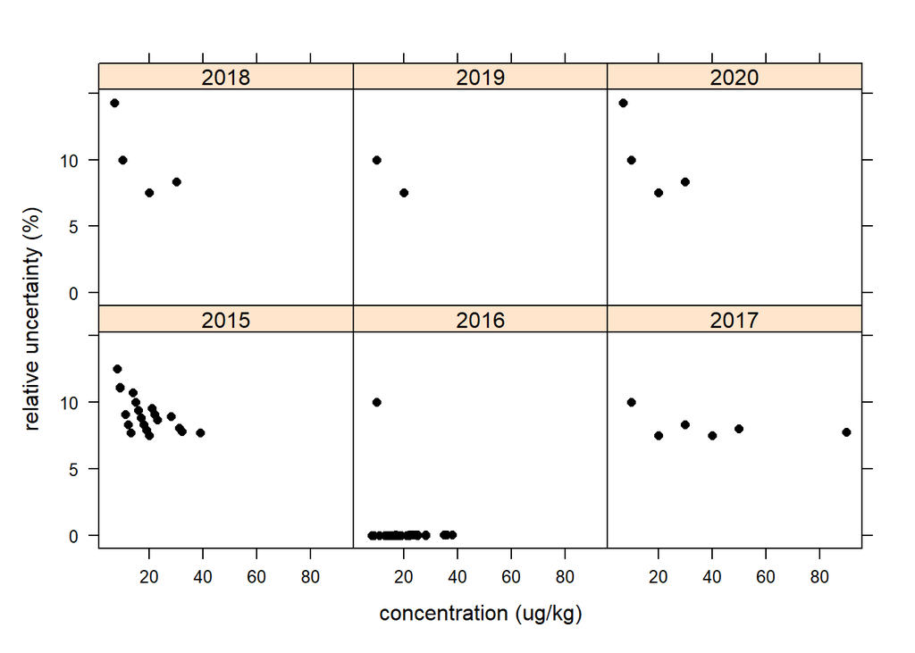

```r
biota_data$data <- mutate(
  biota_data$data,
  .id = country == "Ireland" &
    matrix %in% "SB" &
    year >= 2015 &
    determinand %in% "HG"
)

wk_data <- biota_data$data %>%
  filter(.id) %>%
  mutate(
    relative_uncertainty = case_when(
      methodUncertainty == "SD" ~ 100 * uncertainty / value,
      methodUncertainty == "U2" ~ 100 * uncertainty / (2 * value),
      TRUE                      ~ uncertainty
    ),
    value = convert.units(value, from = unit, to = "ug/kg")
  )

lattice::xyplot(
  jitter(relative_uncertainty) ~ value | as.factor(year),
  data = wk_data,
  ylab = "relative uncertainty (%)",
  xlab = "concentration (ug/kg)",
  scales = list(alternating = FALSE),
  pch = 16, col = "black")
```

The suspicion is that the method of uncertainty has been incorrectly reported as % and should be U2 (as for the other data). Have converted all method of uncertainties to U2 and the relative uncertainties look far more consistent.

```r
wk_data %>%
  with(table(methodUncertainty, year, useNA = "ifany")) %>%
  print(zero.print = ".")
```

```
                 year
methodUncertainty 2015 2016 2017 2018 2019 2020
               %     .   46    .    .    .    .
               U2   40    2   21   51   33   35
```

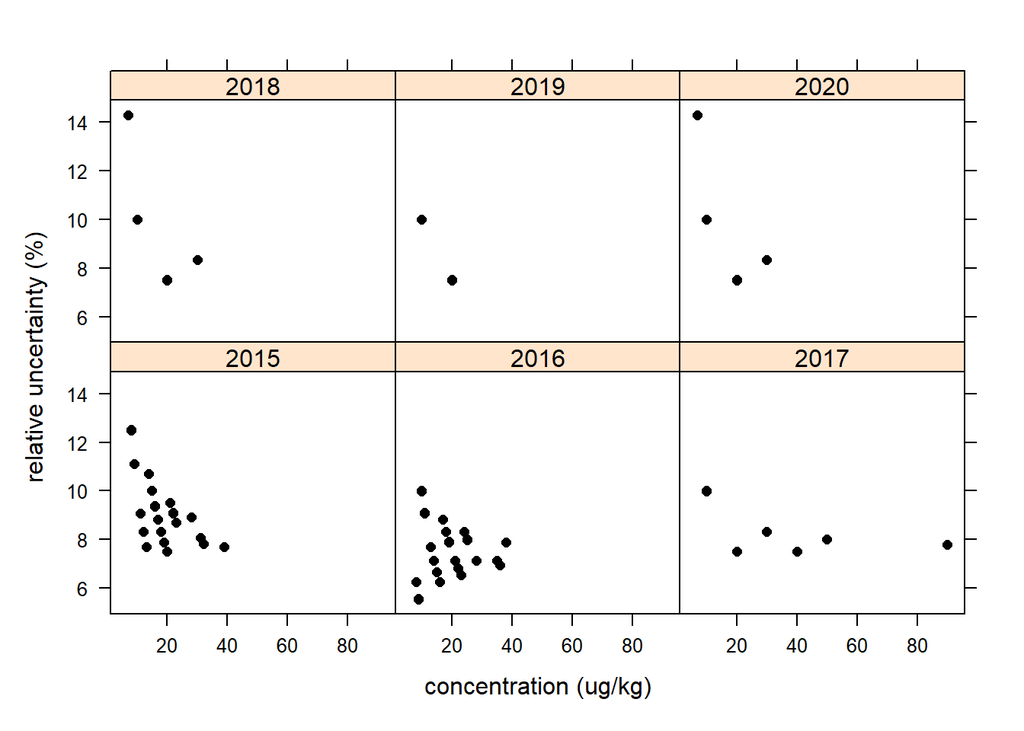

```r
biota_data$data <- mutate(
  biota_data$data,
  methodUncertainty = if_else(.id, "U2", methodUncertainty)
)

# check

wk_data <- biota_data$data %>%
  filter(.id) %>%
  mutate(
    relative_uncertainty = 100 * uncertainty / (2 * value),
    value = convert.units(value, from = unit, to = "ug/kg")
  )

lattice::xyplot(
  jitter(relative_uncertainty) ~ value | as.factor(year),
  data = wk_data,
  ylab = "relative uncertainty (%)",
  xlab = "concentration (ug/kg)",
  scales = list(alternating = FALSE),
  pch = 16, col = "black")
```

```r
biota_data$data <- mutate(biota_data$data, .id = NULL)

rm(wk_data)
```

### Spain: hake mercury

Mercury in hake muscle was measured on a wet weight basis until 2011 (along with dry weight content). However, in 2016 mercury was measured on a dry weight basis (and dry weight content was not measured). The inability to convert these data to a wet weight basis means that the time series will not be used and spatial coverage will be reduced.

The dry weight content from 2007-2011 was pretty consistent so has been used to convert the mercury measurements from 2016 to a wet weight basis. Note that the uncertainty of the converted wet weight measurements should be increased to account for the variation in dry weight content between fish, but for expediency this has not been done. Also, the conversion to wet weight assumes that there is no trend in dry weight content, an assumption that becomes increasingly difficult to justify over time.

Here are the number of mercury and dry weight measurements by year

```r
biota_data$data <- mutate(
  biota_data$data,
  .id = country == "Spain" &
    species == "Merluccius merluccius" &
    matrix == "MU" &
    year >= 2000
)

wk_data <- filter(
  biota_data$data,
  .id & determinand %in% c("HG", "DRYWT%")
)

if (any(wk_data$determinand %in% "HG" & wk_data$basis %in% "D" & wk_data$year != 2016))
  stop("something has changed - investigate")

if (!all(na.omit(wk_data$methodUncertainty) %in% "U2"))
  stop("something has changed - investigate")

wk_data %>%
  with(table(determinand, year)) %>%
  print(zero.print = ".")
```

```
           year
determinand 2007 2008 2009 2010 2011 2016
     DRYWT%   36   13   57   44   40    .
     HG       36   13   57   43   40   72
```

And the number of mercury measurements by year and basis.

```r
wk_data %>%
  filter(determinand %in% "HG") %>%
  with(table(basis, year)) %>%
  print(zero.print = ".")
```

```
     year
basis 2007 2008 2009 2010 2011 2016
    D    .    .    .    .    .   72
    W   36   13   57   43   40    .
```

Here is a plot of dry weight content by station and year.

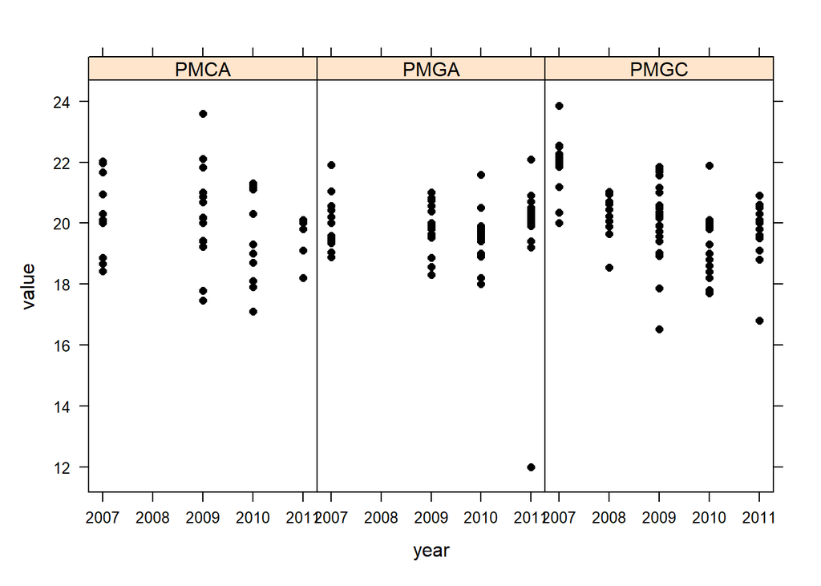

```r
wk_data <- filter(wk_data, determinand %in% "DRYWT%")

lattice::xyplot(
  value ~ year | station_name,
  wk_data,
  pch = 16,
  col = "black",
  scales = list(alternating = FALSE)
)
```

The median dry weight content is very similar across stations:

```r
wk_dw <- median(wk_data$value)

with(wk_data, tapply(value, station_name, median))
```

```
PMCA PMGA PMGC
20.0 19.9 20.1
```

Therefore use the median value across the whole data set (20%) to convert. Also have to convert uncertainty (which has been reported as U2). Limits of detection and quantification are set to missing so they do not affect the calculations for imputing missing uncertainties.

```r
biota_data$data <- mutate(
  biota_data$data,
  .id = .id &
    determinand %in% "HG" &
    basis %in% "D",
  value = convert.basis(value, basis, "W", wk_dw, "", exclude = !.id),
  uncertainty = convert.basis(uncertainty, basis, "W", wk_dw, "", exclude = !.id),
  limit_detection = if_else(.id, NA_real_, limit_detection),
  limit_quantification = if_else(.id, NA_real_, limit_quantification),
  basis = if_else(.id, "W", basis),
  .id = NULL
)

rm(wk_data, wk_dw)
```

### Sweden: station names

Two legacy station names have been replaced but it is difficult to resolve this using the station dictionary because the replacement station depends on the species type

- B-R06 has been replaced by E/W FLADEN (fish) and Nidingen (mytilus)
- B-R07 has been replaced by Fjallbacka (mytilus) and Vaderoarna (fish)

Note that eelpout is also sampled at Fjallbacka (so it is not just a shellfish station). Here’s a summary of the measurements that need to be changed.

```r
biota_data$data %>%
  filter(
    country %in% "Sweden",
    submitted.station %in% c("B-R06", "B-R07")
  ) %>%
  select(year, submitted.station, station_name, station_code, speciestype) %>%
  with(table(speciestype, year, submitted.station)) %>%
  print(zero.print = ".")
```

```
, , submitted.station = B-R06

           year
speciestype 1979 1980 1981 1982 1983 1984 1985 1986 1987 1988 1989 1990 1991 1992 1993 1994 1995 1996
    Bivalve    .    .   42   42   52   52    .    .   52   52   52   52   52   52   52   52   40   40
    Fish      57  157  258  258  323  322  323  323  299  323  301  301  301  301  286  310  179   61

, , submitted.station = B-R07

           year
speciestype 1979 1980 1981 1982 1983 1984 1985 1986 1987 1988 1989 1990 1991 1992 1993 1994 1995 1996
    Bivalve    .   42   39   26   50   52   52   52   52   50   52   52   50   52    .   52   50    .
    Fish       .   60   78   60   67   98   27   99   99   99  101  101  101  101  101  101    .   60
```

Here are the station codes for the correct stations

```r
# station codes are hard wired

wk <- biota_data$stations %>%
  filter(
    country %in% "Sweden",
    grepl("CF", dataType),
    station %in% c("E/W FLADEN", "Nidingen") |
      grepl("llbacka", station) |
      (grepl("V", station) & grepl("arna", station))
  ) %>%
  select(code, station) %>%
  column_to_rownames("code")

wk
```

```
        station
6299 E/W FLADEN
5747 Fjällbacka
5955   Nidingen
6141 Väderöarna
```

```r
biota_data$data <- mutate(
  biota_data$data,

  .id = country %in% "Sweden" & submitted.station %in% "B-R06",

  .change = .id & speciestype %in% "Fish",
  station_name = if_else(.change, "E/W FLADEN", station_name),
  station_code = if_else(.change, "6299", station_code),

  .change = .id & speciestype %in% "Bivalve",
  station_name = if_else(.change, "Nidingen", station_name),
  station_code = if_else(.change, "5955", station_code),

  .id = country %in% "Sweden" & submitted.station %in% "B-R07",

  .change = .id & speciestype %in% "Fish",
  station_name = if_else(.change, wk["6141", "station"], station_name),
  station_code = if_else(.change, "6141", station_code),

  .change = .id & speciestype %in% "Bivalve",
  station_name = if_else(.change, wk["5747", "station"], station_name),
  station_code = if_else(.change, "5747", station_code),

  .id = NULL,
  .change = NULL
)
```

And here is a summary of the measurements at the correct stations.

```r
biota_data$data %>%
  filter(station_code %in% row.names(wk)) %>%
  select(year, submitted.station, station_name, station_code, speciestype) %>%
  with(table(speciestype, year, station_name)) %>%
  print(zero.print = ".")
```

```
, , station_name = E/W FLADEN

           year
speciestype 1979 1980 1981 1982 1983 1984 1985 1986 1987 1988 1989 1990 1991 1992 1993 1994 1995 1996
    Bivalve    .    .    .    .    .    .    .    .    .    .    .    .    .    .    .    .    .    .
    Fish      57  157  258  258  323  322  323  323  299  323  301  301  301  301  286  310  179   61
           year
speciestype 1997 1998 1999 2000 2001 2002 2003 2004 2005 2006 2007 2008 2009 2010 2011 2012 2013 2014
    Bivalve    .    .    .    .    .    .    .    .    .    .    .    .    .    .    .    .    .    .
    Fish     110  118  125  110  126  118  126  126  110   97   60   50   76  136  136  125  114   80
           year
speciestype 2016 2017 2018 2019
    Bivalve    .    .    .    .
    Fish      74   74   82   75

, , station_name = Fjällbacka

           year
speciestype 1979 1980 1981 1982 1983 1984 1985 1986 1987 1988 1989 1990 1991 1992 1993 1994 1995 1996
    Bivalve    .   42   39   26   50   52   52   52   52   50   52   52   50   52    .   52   50    .
    Fish       .    .    .    .    .    .    .    .    .    .    .    .    .    .    .    .    .    .
           year
speciestype 1997 1998 1999 2000 2001 2002 2003 2004 2005 2006 2007 2008 2009 2010 2011 2012 2013 2014
    Bivalve   38   50   53   50   45   53   37   45   54   53   45   45   56   56   56   36   56   24
    Fish      40   50    .   50   50   50   50   50   50   50    .    .    .   12    8   10   10    6
           year
speciestype 2016 2017 2018 2019
    Bivalve   56   56   36   36
    Fish      10   10   10   10

, , station_name = Nidingen

           year
speciestype 1979 1980 1981 1982 1983 1984 1985 1986 1987 1988 1989 1990 1991 1992 1993 1994 1995 1996
    Bivalve    .    .   42   42   52   52    .    .   52   52   52   52   52   52   52   52   40   40
    Fish       .    .    .    .    .    .    .    .    .    .    .    .    .    .    .    .    .    .
           year
speciestype 1997 1998 1999 2000 2001 2002 2003 2004 2005 2006 2007 2008 2009 2010 2011 2012 2013 2014
    Bivalve   50   50   53   50   53   53    .   53   98   42   53   30   57   56   45   36   56   41
    Fish       .    .    .    .    .    .    .    .    .    .    .    .    .    .    .    .    .    .
           year
speciestype 2016 2017 2018 2019
    Bivalve   56   56   36   36
    Fish       .    .    .    .

, , station_name = Väderöarna

           year
speciestype 1979 1980 1981 1982 1983 1984 1985 1986 1987 1988 1989 1990 1991 1992 1993 1994 1995 1996
    Bivalve    .    .    .    .    .    .    .    .    .    .    .    .    .    .    .    .    .    .
    Fish       .   60   78   60   67   98   27   99   99   99  101  101  101  101  101  101    .   60
           year
speciestype 1997 1998 1999 2000 2001 2002 2003 2004 2005 2006 2007 2008 2009 2010 2011 2012 2013 2014
    Bivalve    .    .    .    .    .    .    .    .    .    .    .    .    .    .    .    .    .    .
    Fish     100  100  100  100  100  100   99  100  100    .   60   50   76   75   76   76   64   40
           year
speciestype 2016 2017 2018 2019
    Bivalve    .    .    .    .
    Fish      63   62   12   12
```

```r
rm(wk)
```